# KİT Sisteminin İktisadi Değerlendirmesi

Erol Taymaz  
İktisat Bölümü, Orta Doğu Teknik Üniversitesi  
http://users.metu.edu.tr/etaymaz

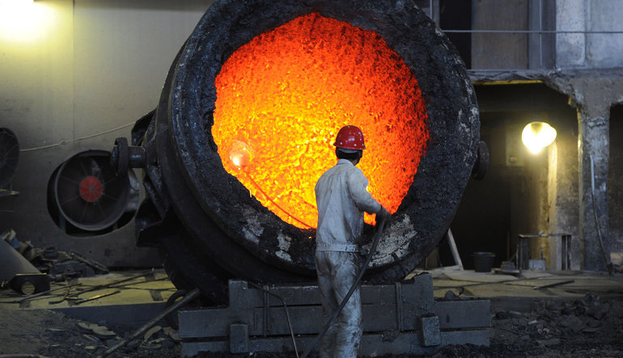

TMMOB Kamucu Politikalar Sempozyumu, 22-23 Kasım 2019, Ankara

# Sunum planı

- Niçin KİT?
- Türkiye’de KİT’lerin konumu
- KİT’ler ve üretkenlik
- Sonuçlar

# Niçin KİT?

- Ekonomik nedenler
  - Doğal tekel
  - Kamusal mal
  - Gelir elde edilmesi
  - Sermaye birikiminin yetersiz olması
  - Sanayi politikası aracı
- Politik nedenler
  - “Stratejik” sektörler
  - Kamu mülkiyetinin yaygınlaşması

# KİT’ler ve ekonomik etkinlik

- Kamu-özel performans farkı
  - Ekonomi dışı (rasyonel olmayan) hedefler
  - Siyasi baskı, yanlış yatırım/fazla istihdam/aşırı ücret
  - Üretken olmak için yeterli teşvik/baskı yok
    - KİT’ler üzerinde rekabetçi baskı zayıf
  - Sermaye kısıtının bağlayıcı olmaması, yatırım ölçeği
- Performans tanımları
  - Kârlılık
  - Üretkenlik
  - Yenilik/bilgi birikimi

# Çalışmanın kapsamı ve veri kaynakları

- Türkiye imalat sanayii, 1983-2001
- TUİK Yıllık İmalat Sanayii Anketleri
  - Tüm kamu işyeleri ve 10+ kişi çalıştıran özel işyerleri

# KİT’leri konumu

İmalat sanayiinde KİT’lerin sayısı (işyeri)

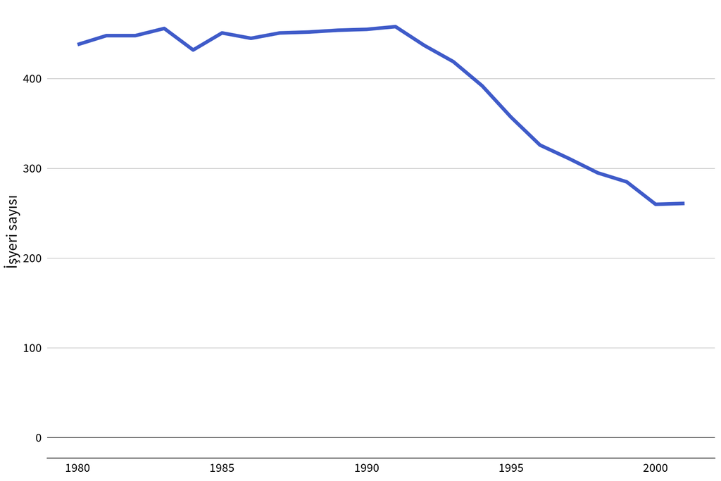

# KİT’leri konumu

KİT’lerin imalat sanayii katma değer ve istihdam payı

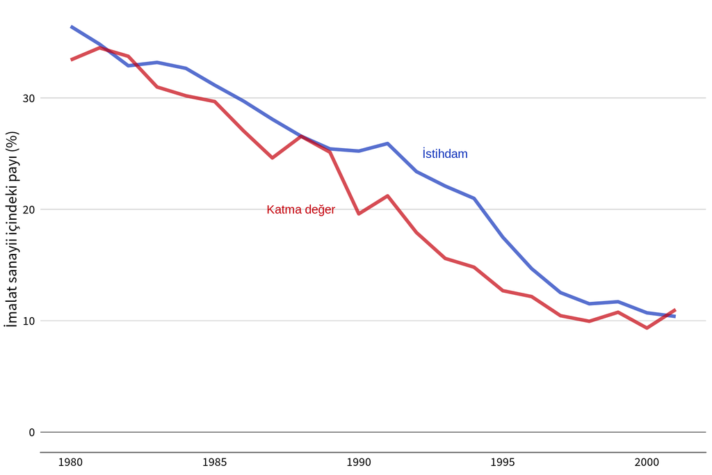

# KİT’leri konumu

KİT’lerin göreli işgücü üretkenliği ve ücretler

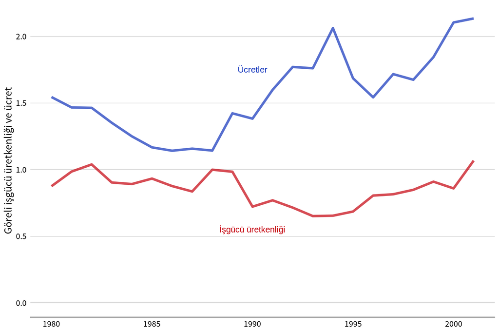

# Sektörel dağılım

KİT’lerin sektörel payı

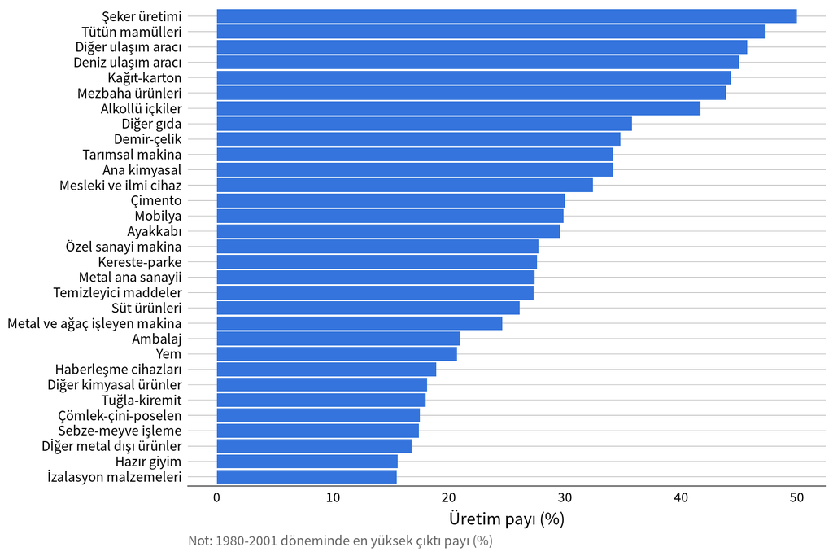

# Sektörel dağılım

KİT’lerin sektörel payı

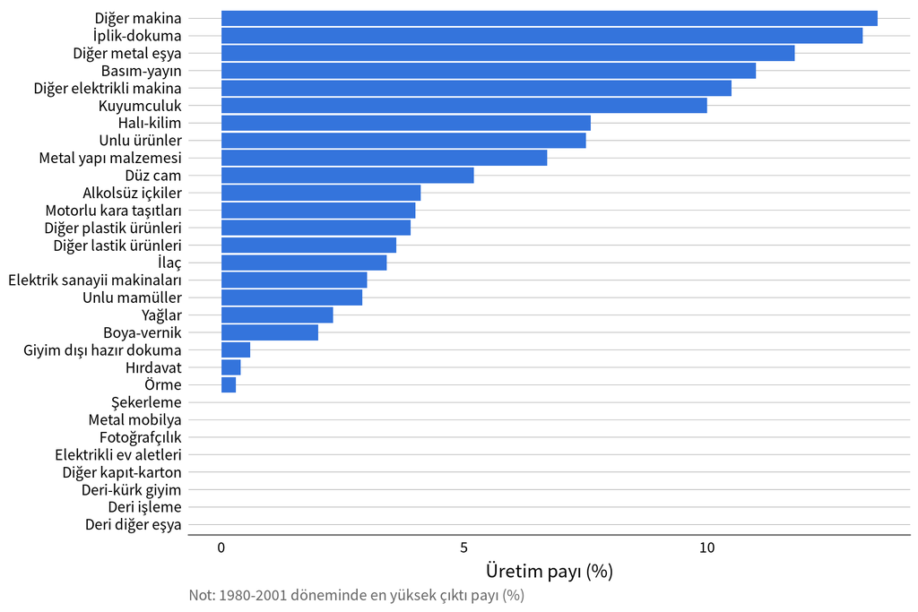

# Özelleştirme

Özelleştirmeden en çok etkilenen sektörler

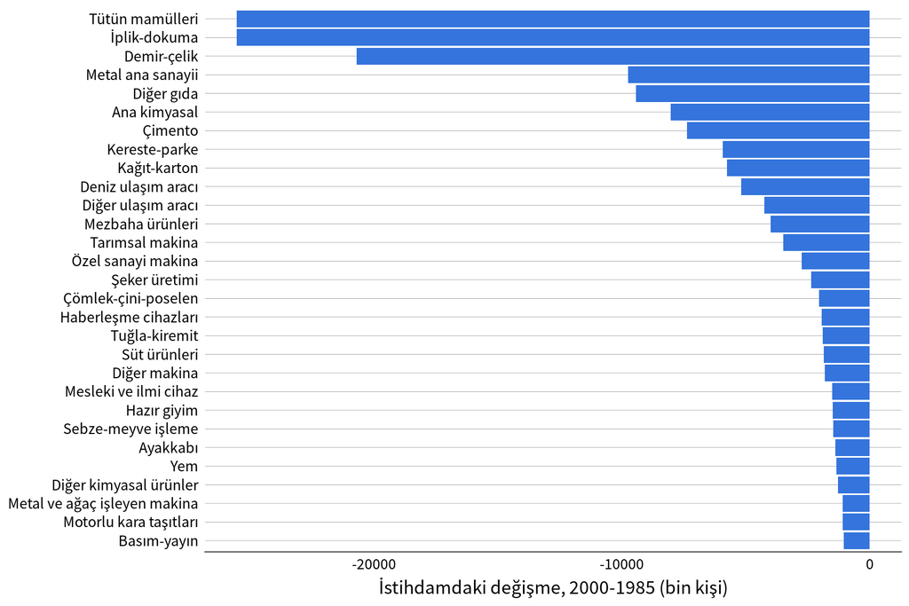

# Bölgesel gelişme

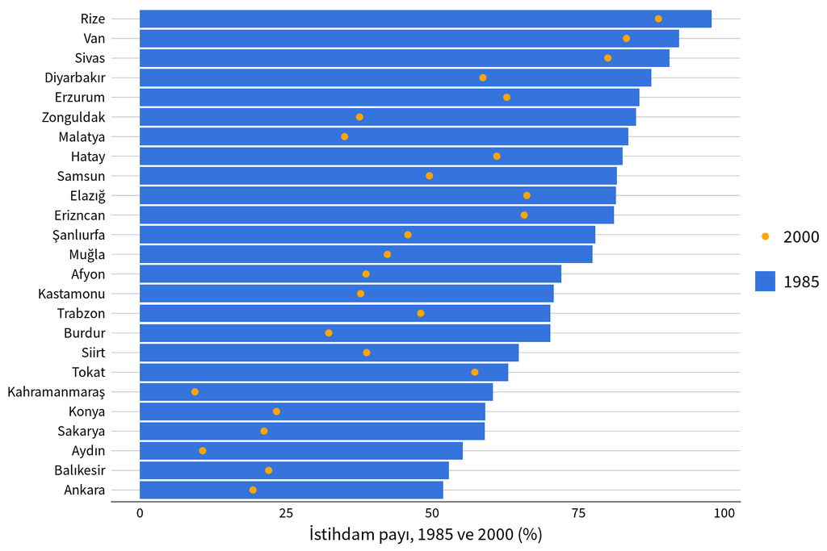

# Bölgesel gelişme

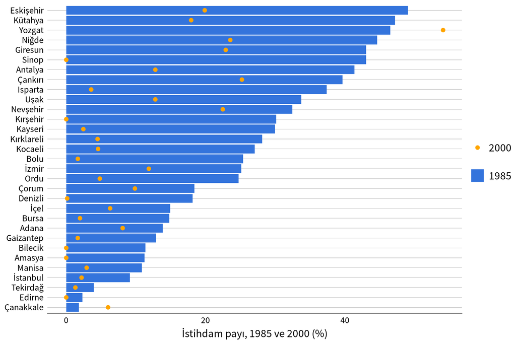

# Üretkenklik

- İşgücü üretkenliği (kişi başına katma değer)
- Toplam faktör verimliliği
  - Üretim sınırı/fonksiyonu tahmini
  - $Q = f(K, L, E, M, t)$
  - ISIC Rev 2. 4-hane düzeyindeki sektörler için translog üretim fonksiyonu tahmini
    - GMM-sistem tahmin yöntemi
    - Elde edilen katsayılardan her işyeri için TFV tahmini
    - Kamu-özel üretkenlik farklılığı
    - Yıllık ortalama üretkenlik artış oranı
    - Ölçeğe göre getiri katsayısı

# Üretkenlik farklılıkları

- Teknolojik farklılıklar
- Yönetim farklılıkları
- Fiyatlama farklılıkları
  - Fiyatı düşük olan işyerlerinin üretkenliği de düşük tahmin ediliyor
- Ürün farklılıkları

# Üretkenlik

KİT’lerin göreli üretkenliği (1983-2001 ortalaması)

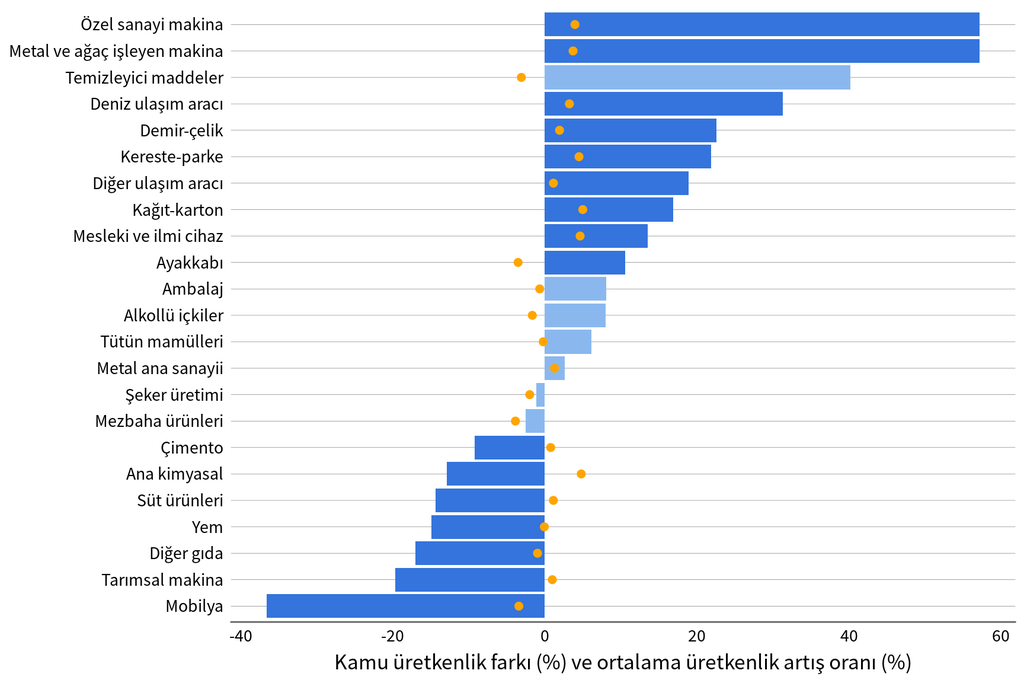

Not: Çubuklar kamu üretkenlik farkını, sarı noktalar ortalama yıllık üretkenlik artış oranını göstermektedir. Şekilde KİT’lerin çıktı payının %20 ve üzerinde olduğu sektörler yer almaktadır.

# Üretkenlik

KİT’lerin göreli üretkenliği (1983-2001 ortalaması)

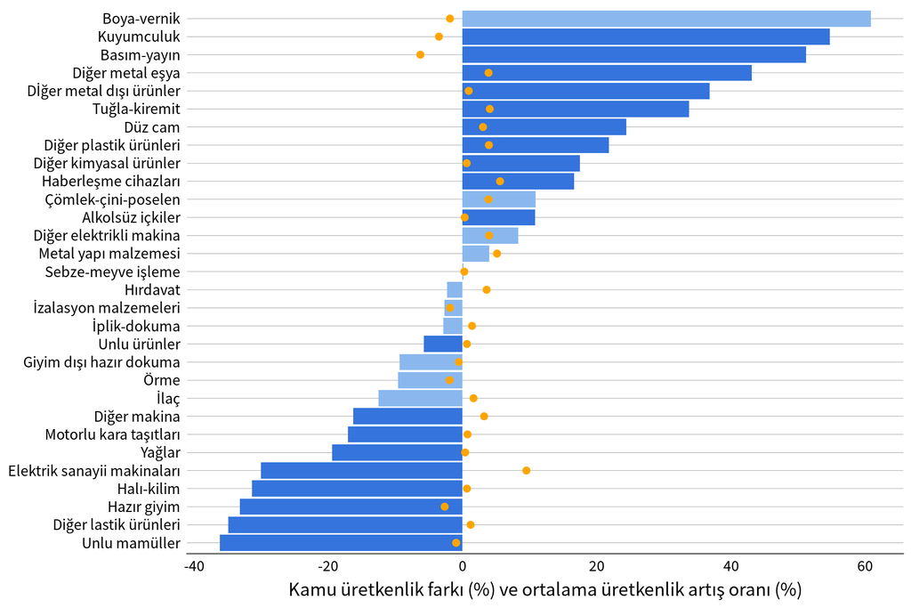

Not: Çubuklar kamu üretkenlik farkını, sarı noktalar ortalama yıllık üretkenlik artış oranını göstermektedir. Şekilde KİT’lerin çıktı payının %20’den az olduğu sektörler yer almaktadır.

# Sonuçlar

- KİT’ler pek çok sektörün geliştirilmesinde önemli
- KİT’ler bölgesel kalkınma açısında önemli
- KİT’ler ile özel işyerleri arasında sistemli bir üretkenlik farklılığı yok
- Fiyat her zaman toplumsal değeri göstermiyor
  - Marjinal maliyetin düşük olduğu durumlar
- KİT’lerin özelleştirilmesi ve kamu girişimciliğinin zayıflaması sanayileşme süreci açısından olumsuz etkide bulundu
- Yeniden kamu girişimciliği?
  - Yeni kamusal alanlar, açık kaynak, açık veri, açık yenilik, açık bilim…